# Informed consent - CESSDA TRAINING

[Consortium of European Social Science Data Archives](https://www.cessda.eu/)

## Informed consent

> The following statement has been adapted from an actual consent form: “**Any information I give will be used for research only and will not be used for any other purpose**“. Consider the implications for data sharing for any data generated using this consent statement. Do you have any suggestions for alternative wording or other changes?

##### Some thoughts on this statement

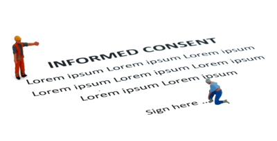

Informed consent is the process by which a researcher discloses appropriate information about the research so that a participant may make a voluntary, informed choice to accept or refuse to cooperate.

Normally informed consent is given before the start of the research. Gaining informed consent is crucial to meeting your legal and ethical obligations towards participants whilst simultaneously enhancing the value of your research data.

To obtain informed consent, researchers should:

- Inform participants about the purpose of the research;
- Discuss what will happen to their contribution (including the future archiving and sharing of their data);
- Indicate the steps that will be taken to safeguard their anonymity and confidentiality;
- Outline their right to withdraw from the research.

Consent needs to be freely given, informed, unambiguous, specific and by a clear affirmative action that signifies agreement to the processing of personal data.

### **Information sheets**

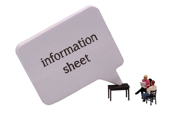

Information sheets play an important role in gaining a participant’s informed consent to take part in a research project. They help provide participants with the background information which is necessary to make an informed decision about whether to take part in the research project.

A good information sheet discusses the following topics:

- The purpose of the research;
- What is involved in participating in the research;
- The benefits and risks of participating in the research;
- Details of the research, e.g. the funding source, sponsoring institution, name of project, contact details for researchers and how to file a complaint;
- The procedures for withdrawing from the research project;
- The planned usage of the data during the research, dissemination, storage, publishing and archiving of the data;
- The strategies for assuring ethical use of the data;
- The procedures for safeguarding personal information, maintaining confidentiality and anonymising data, particularly in relation to data archiving, sharing and reuse.

### Gaining informed consent for data archiving and sharing

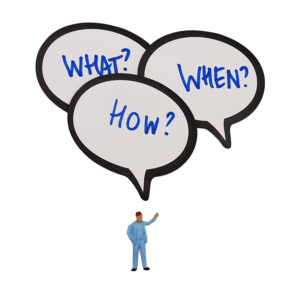

Gaining informed consent for data sharing is seen as 'one more small step' to gaining consent from participants to partake in your research project. As a researcher, you will already be acutely aware of the need to fully inform your participants about:

- What taking part in your research project will involve;
- How you will disseminate information from the project through publications or presentations;
- The impact taking part may have on them.

By adding the discussion of data sharing and archiving you permit the participant to make an informed decision. This empowers them and puts them in charge of choosing whether they wish for their contribution to your research project – and their data – to be available for use in future research projects.

**Granular consent**

The best way to achieve informed consent for data sharing is to identify and explain the possible future uses of their data and offer the participant the option to consent on a granular level. For example, in a qualitative study, this may involve allowing the participant to consent to data sharing of the anonymised transcripts, the non-anonymised audio recordings and the photographs.

Below an example of what granular consent for data sharing could look like on a consent form is detailed:

| **The interviews will be archived at ……………………..…. and disseminated so other researchers can reuse this information for research and learning purposes:** |  |
| --- | --- |
| *I agree to the non-anonymised audio recording of my interview being archived and disseminated for reuse* | *yes/no* |
| *I agree to the anonymised transcript of my interview being archived and disseminated for reuse* | *yes/no* |
| *I agree to any photographs of me taken during interview being archived and disseminated for reuse* | *yes/no* |

### Expert tips

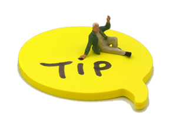

### European diversity in informed consent

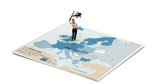